# DS202-FinalProject

Corbin Graham, Coleman Dimmer

2023-12-12

# DS 202 Final Project

**Title: Climate Analysis of Milan, Italy**

**Authors: Corbin Graham, Coleman Dimmer**

The goal of this project is to demonstrate skills learned, in R, analysis of data, demonstration of data, and drawing conclusions from data. We used data from National Centers for Environmental Information (NCEI) for the Milan Weather Recording Station of Milan, Italy. Using graphs, charts, and analysis, we will visualize and demonstrate patterns and trends within the dataset.

## Introduction

The United Nations is an intergovernmental organization whose stated purposes are to maintain international peace and security. They describe themselves as, “the one place on Earth where all the world’s nations can gather together, discuss common problems, and find shared solutions that benefit all of humanity.”(1)

The United Nations, as part of its mission for international peace, has compiled 17 goals, which it deems the most important and of the highest priority for all nations. The goals are ordered by importance to the organization’s purpose. However, all goals should be considered of highest importance for every nation.

The United Nations’ thirteenth goal is on climate action. They state that: “Every person, in every country in every continent will be impacted in some shape or form by climate change. There is a climate cataclysm looming, and we are underprepared for what this could mean.”(1) Thus, this can be seen as a topic of very high importance since, according to the United Nations, climate change will affect us all.

Finding accurate climate data over an extended period can be difficult since most countries did not begin practicing accurate data recording of weather patterns, emissions, until sometime within the last 200 years. For demonstrating, and finding accurate trends, it is important to look at accurate, comprehensive data collection. The most reliable source for climate data available in the United States is the United States National Centers for Environmental Information (NCEI). All the data they provide is extensive, and heavily scrutinized. The rigor of data quality provides us with the best, and most accurate measurements of the climate. Because most quality data recording began recently, we must look outside our borders to find older data with the same accuracy. The longest-running data record on climate comes from Milan, Italy, which began recording weather and climate data in 1763 for the Italian government.

Using this data, it is our goal to demonstrate climate patterns, and find trends in those patterns. Using the trends, we may, or may not find, we hope to find the highest correlating data available to potentially explain the trends we see. While some trends may have no correlation, it is of high likelihood that any trends demonstrated in climate patterns are the result of some external event.

## Data Background

The data set we chose is monthly climate data recorded in Milan, Italy, between January 1763 and November 2008. We can use this data to analyze climate patterns, and possibly use these patterns to correlate with historical/current events that may explain the changes to climate patterns. Do keep in mind, this is one of one thousand data sets meaning this is only a fraction of the total data resource for researchers, scientists, and those seeking to understand and analyze climate patterns and changes.

The original data set has different information regarding both temperature and precipitation data, with further on more information about specific weather observations in the months. Since this based on a month-by-month set throughout the years, we can see patterns, even in older years, as long as only a few data points are missing.

### Dataset

[Milan Weather Recording Station from NCEI (https://www.ncei.noaa.gov/access/search/data-search/global-summary-of-the-month?startDate=1800-01-03T00:00:00&endDate=1800-01-03T23:59:59)](https://www.ncei.noaa.gov/access/search/data-search/global-summary-of-the-month?startDate=1800-01-03T00:00:00&endDate=1800-01-03T23:59:59)

### Column Background

**Degree Days**

- Degree Days: days in a month where the temperature is above or below the mean temperature for that month, measured in points where each point is a degree above or below the mean.
- Degree Cooling Days: days of the month with a temperature below that month’s mean
- Degree Heating Days: days of the month with a temperature above that month’s mean

**Temperature**

**Location**

- Station: Unique station ID; where data was collected
- Name: Name of station; where data was collected
- Date: Year and month data was collected
- Latitude/Longitude/Elevation: Coordinates for station

**Precipitation**

- PRCP: Total precipitation for a month
- EMXP: Highest amount of precipitation in a given year
- EMXP: Lowest amount of precipitation in a given year

### Actual Columns

- Extreme maximum precipitation
- Extreme maximum temperature
- Precipitation
- Number days with maximum temperature greater than 90F (32.2C)
- Number days with greater than 0.10 inch (2.54mm) of precipitation
- Heating Degree Days Season to TIME
- Heating Degree Days
- Number days with maximum temperature greater than 70F (21.1C)
- Cooling Degree Days Season to Date
- Number days with greater than 0.01 inch (0.25mm) of precipitation
- Day of month of highest daily total of precipitation
- Extreme minimum temperature
- Number days with minimum temperature less than 32F (0C)
- Number days with minimum temperature less than 0F (-17.6C)
- Day of month with extreme maximum temperature
- Number days with maximum temperature less than 32F (0C)
- Number days with greater than 1.00 inch (25.4mm) of precipitation
- Cooling Degree Days
- Average Maximum Temperature
- Average Average Temperature
- Average Minimum Temperature
- Day of month of extreme minimum temperature

## Importing Data

Now that we have determined the dataset we wish to use, it is as simple as downloading it from the official source found to the CSV format. This allows us to easily import it as a malleable object.

#### Importanting Libraries

```r
library(tidyverse)
```

```r
library(dplyr)
library(ggplot2)
```

The libraries we are using are for inline operations, and plotting.

#### Important Data from CSV

```r
data <- read_csv("milan.csv")
head(data)
```

```
## # A tibble: 6 × 50
##   STATION   DATE  LATITUDE LONGITUDE ELEVATION NAME   CDSD CDSD_ATTRIBUTES  CLDD
##   <chr>     <chr>    <dbl>     <dbl>     <dbl> <chr> <dbl> <chr>           <dbl>
## 1 ITE00100… 1763…     45.5      9.19       150 MILA…   0   E                 0
## 2 ITE00100… 1763…     45.5      9.19       150 MILA…   0   E                 0
## 3 ITE00100… 1763…     45.5      9.19       150 MILA…   0   E                 0
## 4 ITE00100… 1763…     45.5      9.19       150 MILA…   0   E                 0
## 5 ITE00100… 1763…     45.5      9.19       150 MILA…   7.4 E                 7.4
## 6 ITE00100… 1763…     45.5      9.19       150 MILA…  78   E                70.6
## # ℹ 41 more variables: CLDD_ATTRIBUTES <chr>, DP01 <dbl>,
## #   DP01_ATTRIBUTES <chr>, DP10 <dbl>, DP10_ATTRIBUTES <chr>, DP1X <dbl>,
## #   DP1X_ATTRIBUTES <chr>, DT00 <dbl>, DT00_ATTRIBUTES <chr>, DT32 <dbl>,
## #   DT32_ATTRIBUTES <chr>, DX32 <dbl>, DX32_ATTRIBUTES <chr>, DX70 <dbl>,
## #   DX70_ATTRIBUTES <chr>, DX90 <dbl>, DX90_ATTRIBUTES <chr>, DYNT <dbl>,
## #   DYNT_ATTRIBUTES <chr>, DYXP <dbl>, DYXP_ATTRIBUTES <chr>, DYXT <dbl>,
## #   DYXT_ATTRIBUTES <chr>, EMNT <dbl>, EMNT_ATTRIBUTES <chr>, EMXP <dbl>, …
```

Since we have already downloaded our data to a CSV file, we only need to import it from that file.

#### Data Time Frame

```r
min(data$DATE)
```

```
## [1] "1763-01"
```

```r
max(data$DATE)
```

```
## [1] "2008-11"
```

This function returns the first, and last date in the dataset. The first date is January, 1763, and the final date is November, 2008.

#### Data Columns

```r
colnames(data)
```

```
##  [1] "STATION"         "DATE"            "LATITUDE"        "LONGITUDE"
##  [5] "ELEVATION"       "NAME"            "CDSD"            "CDSD_ATTRIBUTES"
##  [9] "CLDD"            "CLDD_ATTRIBUTES" "DP01"            "DP01_ATTRIBUTES"
## [13] "DP10"            "DP10_ATTRIBUTES" "DP1X"            "DP1X_ATTRIBUTES"
## [17] "DT00"            "DT00_ATTRIBUTES" "DT32"            "DT32_ATTRIBUTES"
## [21] "DX32"            "DX32_ATTRIBUTES" "DX70"            "DX70_ATTRIBUTES"
## [25] "DX90"            "DX90_ATTRIBUTES" "DYNT"            "DYNT_ATTRIBUTES"
## [29] "DYXP"            "DYXP_ATTRIBUTES" "DYXT"            "DYXT_ATTRIBUTES"
## [33] "EMNT"            "EMNT_ATTRIBUTES" "EMXP"            "EMXP_ATTRIBUTES"
## [37] "EMXT"            "EMXT_ATTRIBUTES" "HDSD"            "HDSD_ATTRIBUTES"
## [41] "HTDD"            "HTDD_ATTRIBUTES" "PRCP"            "PRCP_ATTRIBUTES"
## [45] "TAVG"            "TAVG_ATTRIBUTES" "TMAX"            "TMAX_ATTRIBUTES"
## [49] "TMIN"            "TMIN_ATTRIBUTES"
```

This function prints out all of the column names in the original dataset.

## Cleaning Data

Now that we have successfully imported the data, we will clean up our data object so our results are more accurate, and understandable.

#### Finding Important Variables

To ‘weed out’ invaluable variables, we will search for variables that lack the proper time frame, are null, or incomplete.

```r
# Determining if the location value changes
print("Latitude:")
```

```
## [1] "Latitude:"
```

```r
unique(data$LATITUDE)
```

```
## [1] 45.4717
```

```r
print("Longitude:")
```

```
## [1] "Longitude:"
```

```r
unique(data$LONGITUDE)
```

```
## [1] 9.1892
```

```r
# Determine if all variables have the same time frame
print("Number of NA values per column:")
```

```
## [1] "Number of NA values per column:"
```

```r
colSums(is.na(data))
```

```
##         STATION            DATE        LATITUDE       LONGITUDE       ELEVATION
##               0               0               0               0               0
##            NAME            CDSD CDSD_ATTRIBUTES            CLDD CLDD_ATTRIBUTES
##               0             227             238              50              50
##            DP01 DP01_ATTRIBUTES            DP10 DP10_ATTRIBUTES            DP1X
##            1139            1139            1139            1139            1139
## DP1X_ATTRIBUTES            DT00 DT00_ATTRIBUTES            DT32 DT32_ATTRIBUTES
##            1139              14              14              14              14
##            DX32 DX32_ATTRIBUTES            DX70 DX70_ATTRIBUTES            DX90
##              18              18              18              18              18
## DX90_ATTRIBUTES            DYNT DYNT_ATTRIBUTES            DYXP DYXP_ATTRIBUTES
##              18              14              14            1139            1139
##            DYXT DYXT_ATTRIBUTES            EMNT EMNT_ATTRIBUTES            EMXP
##              18              18              14              14            1139
## EMXP_ATTRIBUTES            EMXT EMXT_ATTRIBUTES            HDSD HDSD_ATTRIBUTES
##            1139              18              18             288             293
##            HTDD HTDD_ATTRIBUTES            PRCP PRCP_ATTRIBUTES            TAVG
##              50              50            1139            1139              27
## TAVG_ATTRIBUTES            TMAX TMAX_ATTRIBUTES            TMIN TMIN_ATTRIBUTES
##              27              18              18              14              14
```

#### Creating a Clean Object

```r
#Grabs data and names columns to more reasonable col names. NOTE: DX and DY values are in degrees F, so changed to more accurate degrees C titles to match all other vars.
milanClimate <- data %>%
  select(
    DATE,
    MEAN = TAVG,
    MEAN_MAX = TMAX,
    MEAN_MIN = TMIN,
    HEAT_DEG_DAYS = HTDD,
    COOL_DEG_DAYS = CLDD,
    HIGHEST_TEMP = EMXT,
    HIGHEST_DAY = EMXT_ATTRIBUTES,
    COOLEST_TEMP = EMNT,
    COOLEST_DAY = EMNT_ATTRIBUTES,
    GTE_32 = DX90,
    GTE_21 = DX70,
    GTE_00 = DX32,
    LTE_00 = DT32,
    LTE_N18 = DT00
  )

# Change the date column into a more usable format.
milanClimate$DATE <- lubridate::ym(milanClimate$DATE)

# Clean and remove unnessicary character in this attribute.
milanClimate$HIGHEST_DAY <- as.numeric(substr(gsub('\\D','',milanClimate$HIGHEST_DAY), nchar(gsub('\\D','',milanClimate$HIGHEST_DAY))-1, nchar(gsub('\\D','',milanClimate$HIGHEST_DAY))))

# Clean and remove unnessicary character in this attribute.
milanClimate$COOLEST_DAY <- as.numeric(substr(gsub('\\D','',milanClimate$COOLEST_DAY), nchar(gsub('\\D','',milanClimate$COOLEST_DAY))-1, nchar(gsub('\\D','',milanClimate$COOLEST_DAY))))

# Show cleaned data columns.
colnames(milanClimate)
```

```
##  [1] "DATE"          "MEAN"          "MEAN_MAX"      "MEAN_MIN"
##  [5] "HEAT_DEG_DAYS" "COOL_DEG_DAYS" "HIGHEST_TEMP"  "HIGHEST_DAY"
##  [9] "COOLEST_TEMP"  "COOLEST_DAY"   "GTE_32"        "GTE_21"
## [13] "GTE_00"        "LTE_00"        "LTE_N18"
```

## Marginal Summaries

Now that we have a cleaned data object, we can begin to plot charts to find and demonstrate different trends.

### Data Time Frame

```r
# First Date
subset_min <- milanClimate %>%
  filter(MEAN == min(MEAN, na.rm = TRUE)) %>%
  select(DATE, MEAN, MEAN_MIN, MEAN_MAX)
# subset_min

# Final Date
subset_max <- milanClimate %>%
  filter(MEAN == max(MEAN, na.rm = TRUE)) %>%
  select(DATE, MEAN, MEAN_MIN, MEAN_MAX)
# subset_max

subset_min_max <- bind_rows(subset_min, subset_max)
subset_min_max # Highest and Lowest Temperatures
```

```
## # A tibble: 2 × 4
##   DATE        MEAN MEAN_MIN MEAN_MAX
##   <date>     <dbl>    <dbl>    <dbl>
## 1 1767-01-01 -4.75    -6.72    -2.77
## 2 2006-07-01 31.2     25.8     36.5
```

### Monthly Temperature Range

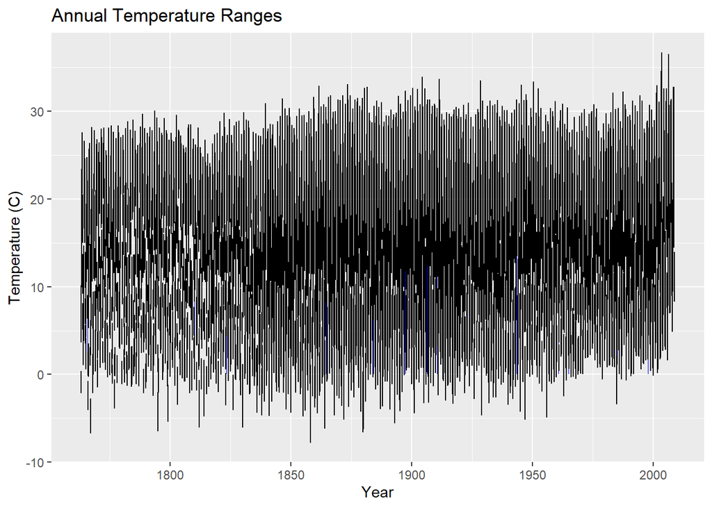

```r
ggplot(milanClimate, aes(x=DATE, y=MEAN)) +
  geom_bar(stat="identity", fill="blue", width=0.5) +
  geom_errorbar(aes(ymin = MEAN_MIN, ymax = MEAN_MAX), width = 0.2, position = position_dodge(width = 0.5)) +
  labs(x="Year", y="Temperature (C)") +
  ggtitle("Annual Temperature Ranges")
```

From this temperature range graph, you can see some trends, especially into the 2000s.

```r
# Create a subset
ex <- milanClimate
ex$DATE <- factor(ex$DATE)

# Extract month and year
ex$Month = month(ex$DATE)
ex$Year = year(ex$DATE)
```

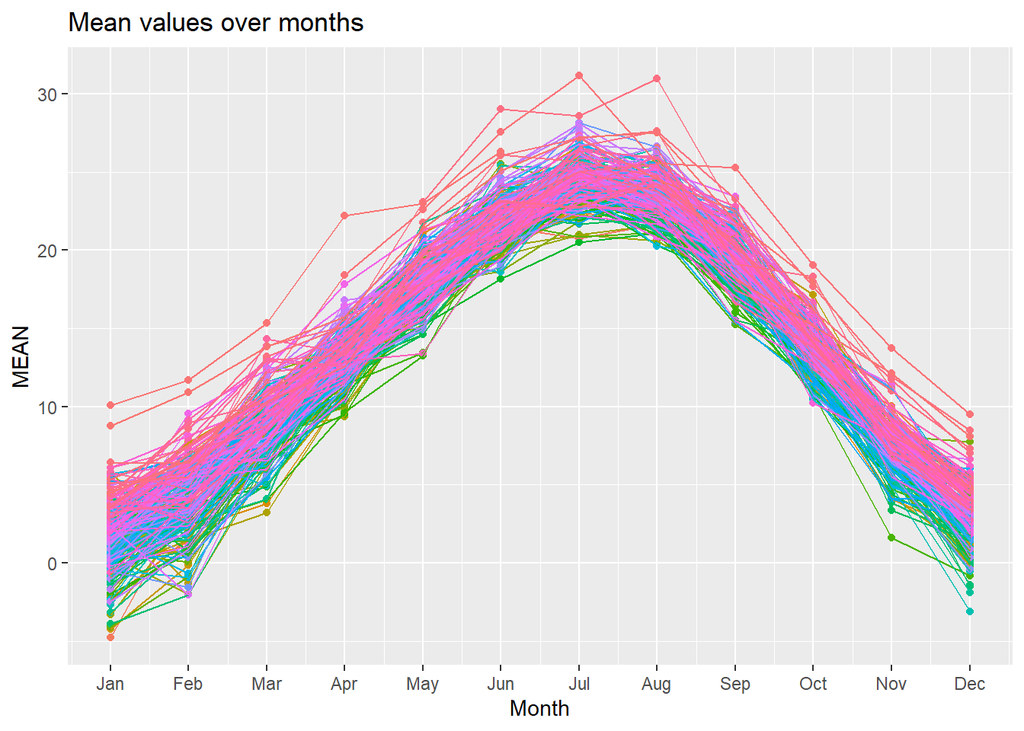

```r
ex$Year = as.numeric(ex$Year)

# Plot the data
ggplot(ex, aes(x = Month, y = MEAN, color = factor(Year))) +
  geom_point() +
  geom_line() +
  scale_x_continuous(breaks = 1:12, labels = month.abb) +  # Set breaks and labels for the x-axis
  labs(x = "Month", y = "MEAN", title = "Mean values over months") +
  theme(legend.position = "none")  # Hide the legend
```

This graph displays the same data as above, but highlights the temperature trend over the year.

### Annual Temperature Trend

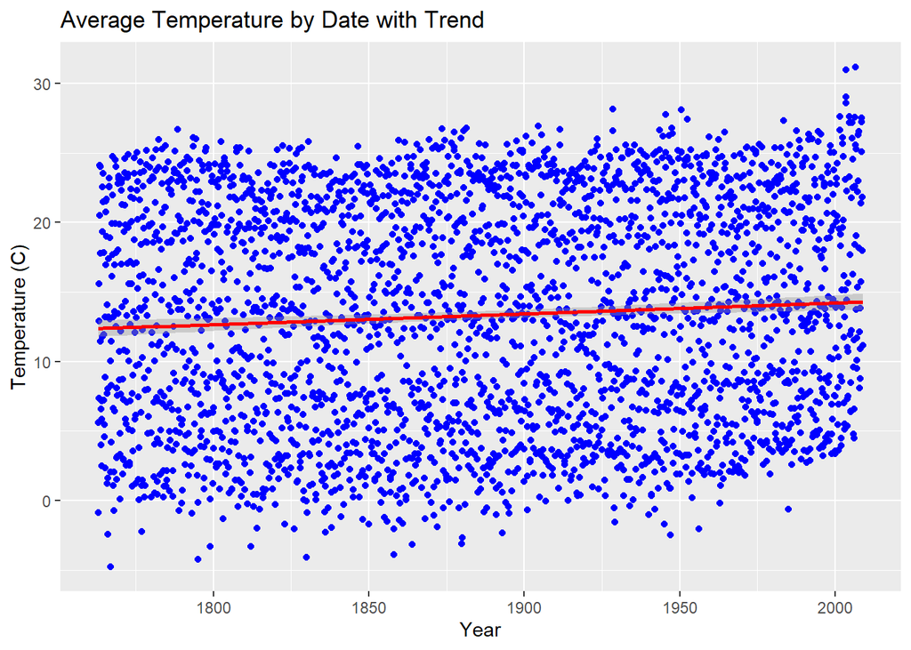

```r
# Monthly averages
ggplot(milanClimate, aes(x=DATE, y=MEAN)) +
  geom_point(color='blue') +
  geom_smooth(method='lm', color='red') +
  labs(x="Year", y="Temperature (C)") +
  ggtitle("Average Temperature by Date with Trend")
```

The above graph shows a clear upwards trend in average temperature over the time frame of the data. Let’s figure out what the exact difference is.

### Increase in Average Temperature

```r
# TODO: Coleman, calculate the average of the last and first year, subtract for average increase

firstLastYear <- milanClimate %>%
    mutate(
      year = year(DATE),
      month = month(DATE)
    ) %>% group_by(year) %>%
  select(year, MEAN) %>%
  summarise(
    averageTemp = mean(MEAN)
  ) %>% filter(
    year == 1763 | year == 2008
  )

Mean2008 <- firstLastYear[[2,2]]
Mean1763 <- firstLastYear[[1,2]]
avgIncrease <- Mean2008 - Mean1763

print(avgIncrease)
```

```
## [1] 5.895379
```

### Average Annual Temperature Trend

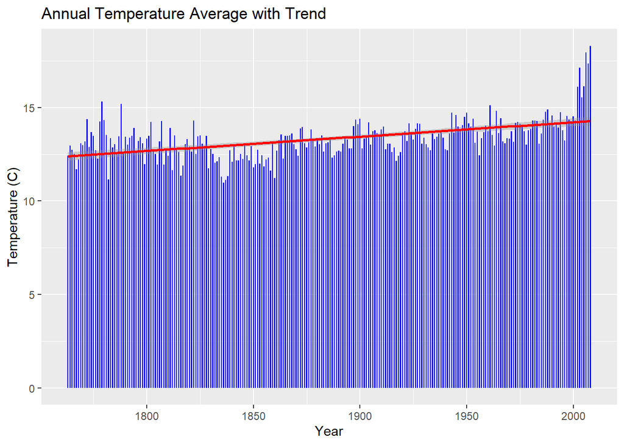

```r
# Extract year from the "date" column
new_data <- milanClimate %>%
  mutate(year = lubridate::year(DATE))

# Create a summary dataframe with yearly statistics
summary_df <- new_data %>%
  group_by(year) %>%
  summarise(
    MEAN = mean(MEAN, na.rm = TRUE),
    MIN = min(MEAN_MIN, na.rm = TRUE),
    MAX = max(MEAN_MAX, na.rm = TRUE)
  )

# Print the summary dataframe
ggplot(summary_df, aes(x=year, y=MEAN)) +
  geom_bar(stat="identity", fill="blue", width=0.5) +
  geom_smooth(method='lm', color='red') +
  labs(x="Year", y="Temperature (C)") +
  ggtitle("Annual Temperature Average with Trend")
```

### Other Elements

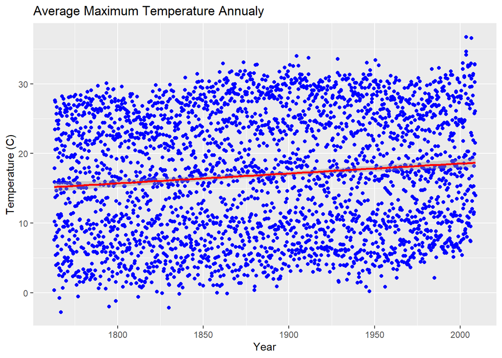

```r
ggplot(milanClimate, aes(x=DATE, y=MEAN_MAX)) +
  geom_point(color='blue') +
  geom_smooth(method='lm', color='red') +
  labs(x="Year", y="Temperature (C)") +
  ggtitle("Average Maximum Temperature Annualy")
```

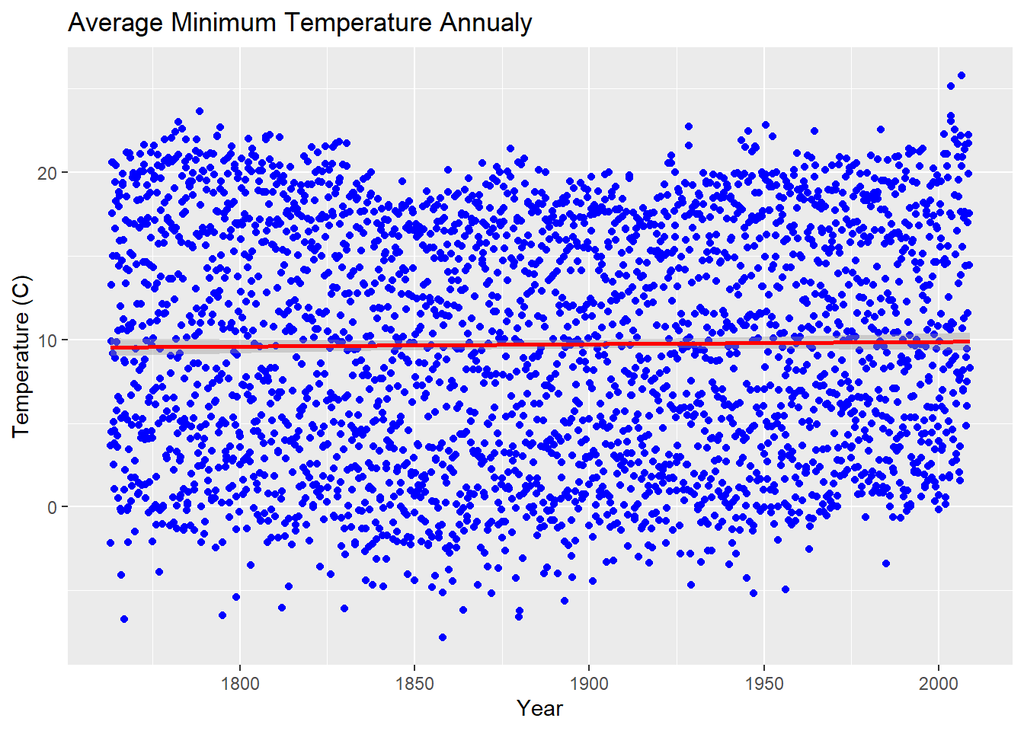

```r
ggplot(milanClimate, aes(x=DATE, y=MEAN_MIN)) +
  geom_point(color='blue') +
  geom_smooth(method='lm', color='red') +
  labs(x="Year", y="Temperature (C)") +
  ggtitle("Average Minimum Temperature Annualy")
```

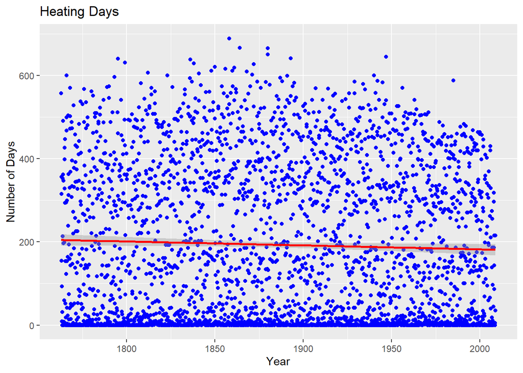

```r
ggplot(milanClimate, aes(x=DATE, y=HEAT_DEG_DAYS)) +
  geom_point(color='blue') +
  geom_smooth(method='lm', color='red') +
  labs(x="Year", y="Number of Days") +
  ggtitle("Heating Days")
```

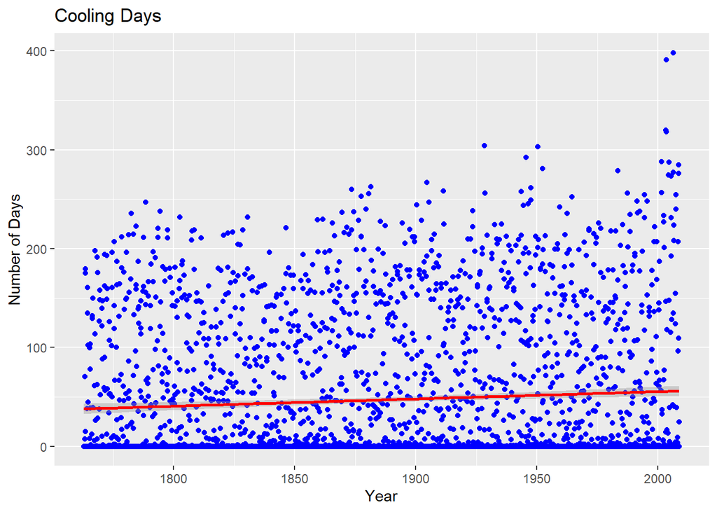

```r
ggplot(milanClimate, aes(x=DATE, y=COOL_DEG_DAYS)) +
  geom_point(color='blue') +
  geom_smooth(method='lm', color='red') +
  labs(x="Year", y="Number of Days") +
  ggtitle("Cooling Days")
```

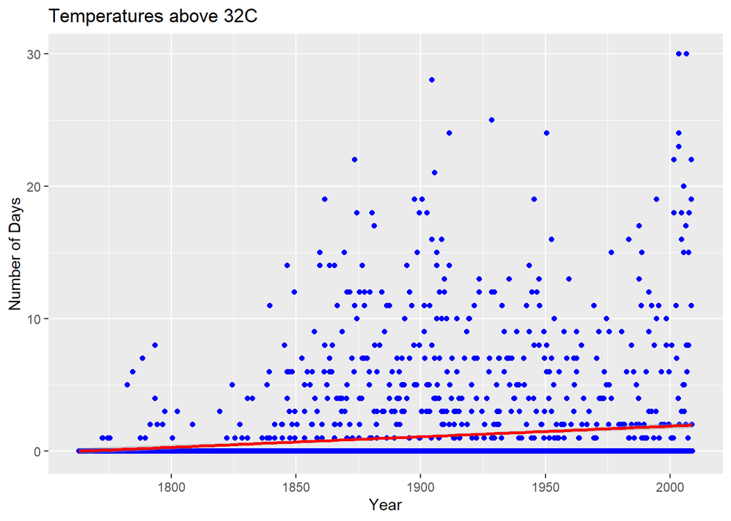

```r
ggplot(milanClimate, aes(x=DATE, y=GTE_32)) +
  geom_point(color='blue') +
  geom_smooth(method='lm', color='red') +
  labs(x="Year", y="Number of Days") +
  ggtitle("Temperatures above 32C")
```

## Investigation

Now that we can see clear trends in the temperature increase, we want to explore some potential factors that influence this shift.

### Milan’s Population

Along with the economic success of Milan, and the rest of Italy, and the return of displaced peoples following WWII, Milan’s population grew rapidly, nearly doubling between 1950 and 1972. With year-over-year population increases of about 5% during this time period, we can also derive a correlation between population growth and these temperatures. (5)

### Other Factors

While industrialization, and population growth appear to play a significant role in the increase of average temperatures in Milan, there are certainly other factors. Going forward, to better understand such factors, it would be ideal to create statistical models that correlate directly between such trends. Searching local and global news from these time periods led us to these conclusions, but there are always unexpected factors that can lead to the same conclusions.

## Conclusion

The United Nations’ concerns appear to have some legitimacy behind them. From our analysis, there were clear trends showing a rise in average temperature in Milan. Increases in average temperature, paired with new extreme highs, as we saw in the graph showing every time the temperature rose above 32 degrees (C), clearly demonstrate a heating climate. Without context, this could be seen as a naturally occurring phenomena until compared with outside sources.

When comparing economic trends, the rise of industrialization, subsequent declination, and return, it is apparent, there is no phenomena occurring. Instead, we see a direct correlation between the population, GDB, economic success, and a rise in temperatures.

The United Nations defines climate change as “Climate change refers to long-term shifts in temperatures and weather patterns. Such shifts can be natural, due to changes in the sun’s activity or large volcanic eruptions. But since the 1800s, human activities have been the main driver of climate change, primarily due to the burning of fossil fuels like coal, oil and gas.” And, as you see year-over-year increases in temperatures, it is indication of some level of climate change.

Going forward, if more were to come of this study, broadening our data would be the first step. To truly find and understand all climate-related trends, we need to assess weather, temperature, local, and global events, carbon emission, green-house gases, and much more. Refining and cleaning data is an important step for finding clear, understandable patterns. How can we look to Milan as an example, and understand how similar trends affect the rest of the world? Can we use former trends to predict future events, or how to mitigate the effects of climate change?

## References

1. United Nations, https://www.un.org/sustainabledevelopment/
2. Milan Weather Recording Station, NCEI, https://www.ncei.noaa.gov/access/search/data-search/global-summary-of-the-month?startDate=1800-01-03T00:00:00&endDate=1800-01-03T23:59:59
3. Industrial Revolution of Milan, Italy https://www.erih.net/how-it-started/industrial-history-of-european-countries/italy#:~:text=The%20Industrial%20Revolution%20swept%20the,plant%20near%20Naples%20in%201908
4. Economic Growth of Italy https://ideas.repec.org/p/pra/mprapa/12817.html
5. Milan Population 2023 https://worldpopulationreview.com/world-cities/milan-population